# DATA 606 - Lab 5A - Sampling Distributions

Preston Peck

2021-10-15

# Sampling Distributions

https://htmlpreview.github.io/?https://github.com/jbryer/DATA606/blob/master/inst/labs/Lab5a/Lab5a_sampling_distributions.html

```r
library(tidyverse)
library(openintro)
library(infer)
library(psych)
```

```r
set.seed(37)

nLabel <- "n"
benefitsLabel <- "Benefits"
doesntBenefitLabel <- "Doesn't benefit"

global_monitor <- tibble(
  scientist_work = c(rep(benefitsLabel, 80000), rep(doesntBenefitLabel, 20000))
)
```

### Exercise 1

The distribution in the smaller sample size is very similar to that of the larger sample size since the proportions of each scientist_work type within its respective set is very close between the data sets

```r
sizeSample <- function(sample, size = NULL) {
  sizedSample <- if(is.null(size)) {
    sample
  } else {
    sample %>%
      sample_n(size)
  }

  return(sizedSample)
}
```

```r
analyzeSamplingProportion <- function(sample, size = NULL) {
  sizedSample <- sizeSample(sample, size)

  sizedSampleProportions <- sizedSample %>%
    count(scientist_work) %>%
    mutate(p = n / sum(n)) %>%
    select(scientist_work, n, p)

  print(sizedSampleProportions)

  print(ggplot(sizedSample, aes(x = scientist_work)) +
    geom_bar() +
    labs(
      x = "",
      y = "",
      title = "Do you believe that the work scientists do benefit people like you?"
    ) +
    coord_flip())

  return(sizedSampleProportions)
}
```

```r
smallNumOfElements = 50
mediumNumOfElements = 100
largeNumOfElements = 1000



global_monitor %>%
  analyzeSamplingProportion
```

```
## # A tibble: 2 × 3
##   scientist_work      n     p
##   <chr>           <int> <dbl>
## 1 Benefits        80000   0.8
## 2 Doesn't benefit 20000   0.2
```

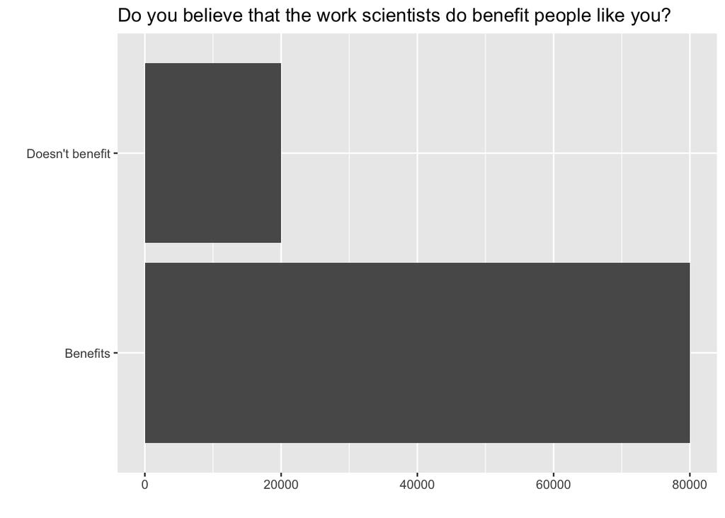

```
## # A tibble: 2 × 3
##   scientist_work      n     p
##   <chr>           <int> <dbl>
## 1 Benefits        80000   0.8
## 2 Doesn't benefit 20000   0.2
```

```r
samp1 <- global_monitor %>%
  analyzeSamplingProportion(smallNumOfElements)
```

```
## # A tibble: 2 × 3
##   scientist_work      n     p
##   <chr>           <int> <dbl>
## 1 Benefits           43  0.86
## 2 Doesn't benefit     7  0.14
```

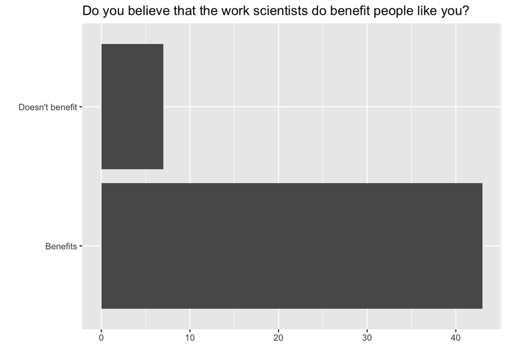

### Exercise 2

With such a small sample size, the proportions will be very prone to changing since small variations can result in big changes, so I can’t say for sure that other students will have the same results, but we will probably have similar results.

### Exercise 3

Larger datasets will be closer to the proportions of the overall population since we’re approaching its size

```r
samp2 <- global_monitor %>%
  analyzeSamplingProportion(smallNumOfElements)
```

```
## # A tibble: 2 × 3
##   scientist_work      n     p
##   <chr>           <int> <dbl>
## 1 Benefits           41  0.82
## 2 Doesn't benefit     9  0.18
```

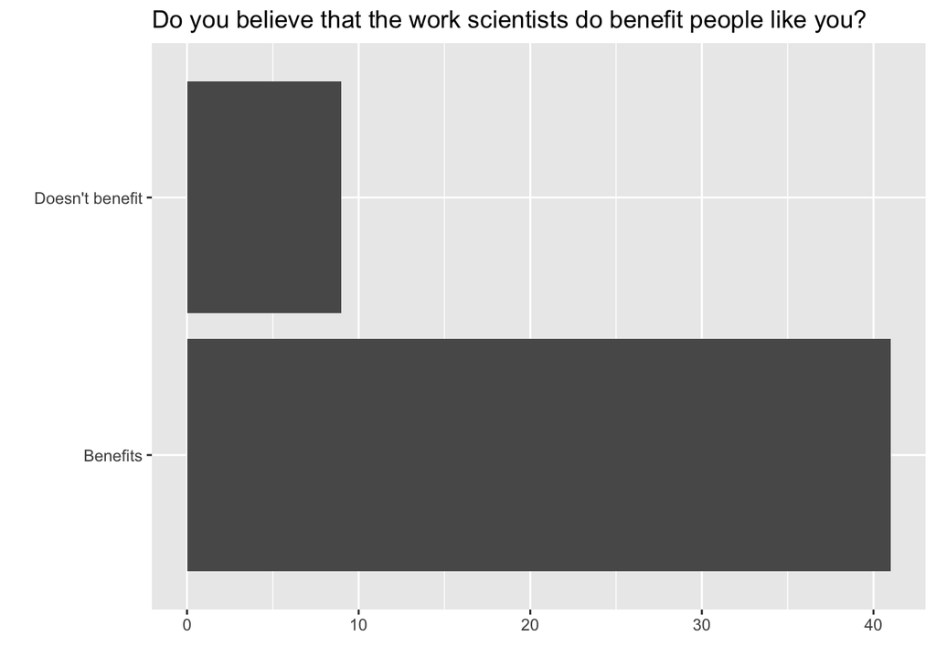

```r
samp3 <- global_monitor %>%
  analyzeSamplingProportion(mediumNumOfElements)
```

```
## # A tibble: 2 × 3
##   scientist_work      n     p
##   <chr>           <int> <dbl>
## 1 Benefits           77  0.77
## 2 Doesn't benefit    23  0.23
```

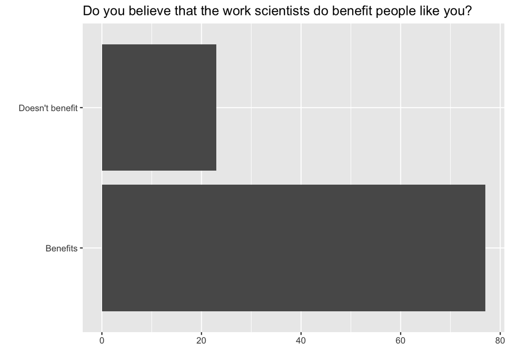

```r
samp4 <- global_monitor %>%
  analyzeSamplingProportion(largeNumOfElements)
```

```
## # A tibble: 2 × 3
##   scientist_work      n     p
##   <chr>           <int> <dbl>
## 1 Benefits          795 0.795
## 2 Doesn't benefit   205 0.205
```

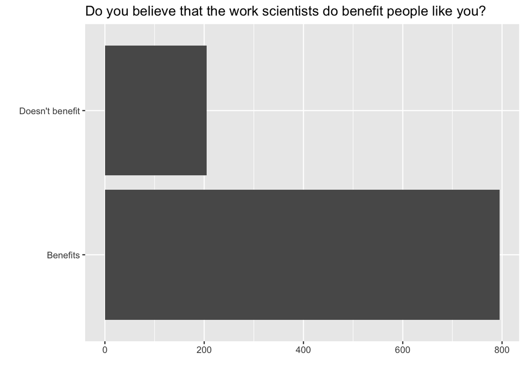